# EDA — Stanford Ribonanza RNA Folding

This notebook provides a **Kaggle‑ready Exploratory Data Analysis (EDA)** for the competition  
**Stanford Ribonanza RNA Folding**.

It focuses on understanding the training dataset structure, sequence properties, and reactivity distributions.

**Goals**

- Inspect the dataset schema (columns, dtypes, memory).
- Assess missing values, experiment types.
- Explore **sequence** properties (length, base composition).
- Examine the distribution of base **reactivity** across the base position, the experiment, and the base nature (i.e., A, C, G, U).
- Extract insights for later feature engineering and modeling.

### Data Path & Plot Setup

This cell loads core libraries, sets the Kaggle dataset path for the Stanford RNA Folding project, prints the path for clarity, and applies consistent matplotlib styling for clean, high-resolution plots.

```python
# === Standard library ===
from pathlib import Path   # filesystem paths
import io                  # buffers/files
import re                  # regular expressions

# === Third-party ===
import numpy as np                     # numerical arrays & math
import pandas as pd                    # tabular data
import matplotlib.pyplot as plt        # plotting
from matplotlib.ticker import MaxNLocator
from matplotlib.patches import Patch
import seaborn as sns                  # statistical plots

# Dataset path (Kaggle)
DATA_PATH = Path('/kaggle/input/stanford-ribonanza-rna-folding/train_data.csv')
print('Using dataset:', DATA_PATH)  # Display active dataset path

# Plot style defaults
plt.rcParams['figure.figsize'] = (8, 4.5)
plt.rcParams['axes.grid'] = True
plt.rcParams['axes.titlesize'] = 12
plt.rcParams['axes.labelsize'] = 11
plt.rcParams['figure.dpi'] = 320
```

```
Using dataset: /kaggle/input/stanford-ribonanza-rna-folding/train_data.csv
```

## 1. Load data

We load the Kaggle competition dataset and identify key columns automatically.

```python
train = pd.read_csv(DATA_PATH)
print('Shape:', train.shape)
print('Columns (first 20):', list(train.columns[:20]))

# Detect key columns
col_sequence = next((c for c in ['sequence', 'seq', 'Sequence'] if c in train.columns), None)
col_exp_type = next((c for c in ['experiment_type', 'exp_type', 'condition'] if c in train.columns), None)
col_dataset = next((c for c in ['dataset_name', 'dataset', 'source'] if c in train.columns), None)
reactivity_cols = [c for c in train.columns if re.match(r'^reactivity_\d+$', str(c))]

print(f"Detected: sequence={col_sequence}, exp_type={col_exp_type}, dataset={col_dataset}")
print(f"Reactivity columns: {len(reactivity_cols)} detected")
```

```
Shape: (1643680, 419)
Columns (first 20): ['sequence_id', 'sequence', 'experiment_type', 'dataset_name', 'reads', 'signal_to_noise', 'SN_filter', 'reactivity_0001', 'reactivity_0002', 'reactivity_0003', 'reactivity_0004', 'reactivity_0005', 'reactivity_0006', 'reactivity_0007', 'reactivity_0008', 'reactivity_0009', 'reac…
Detected: sequence=sequence, exp_type=experiment_type, dataset=dataset_name
Reactivity columns: 206 detected
```

## 2. Data overview

Basic schema and memory usage insights.

```python
# === info print ===
buf = io.StringIO()
train.info(buf=buf)
info_str = buf.getvalue()
print(info_str)

# === memory usage calc ===
mem = (train.memory_usage(deep=True) / (1024**2)).sort_values(ascending=False)
mem_top = mem.head(15)

# === seaborn dark minimalist theme ===
dark_col = "#17191a"
sns.set_theme(style="white", rc={
    "axes.facecolor": dark_col,
    "figure.facecolor": dark_col,
    "axes.grid": False
})

plt.figure(figsize=(7,5))
ax = sns.barplot(
    x=mem_top.values,
    y=mem_top.index,
    alpha=0.85,
    orient="h",
    edgecolor=None,   # <-- remove bar stroke
    linewidth=0       # <-- ensure no outline even if seaborn tries
)

# Axis + text styling
ax.set_title("Top columns by memory usage (MB)", color="white", pad=6)
ax.set_xlabel("MB", color="white", labelpad=6)
ax.set_ylabel("", color="white")
ax.tick_params(colors="white", length=3, width=1, pad=3)

# Keep left + bottom spine only
for spine in ["top", "right"]:
    ax.spines[spine].set_visible(False)
ax.spines["left"].set_color("white")
ax.spines["bottom"].set_color("white")

plt.tight_layout()
plt.savefig("Top_columns.png", bbox_inches="tight")
plt.show()
```

[output not shown]

```
<class 'pandas.core.frame.DataFrame'>
RangeIndex: 1643680 entries, 0 to 1643679
Columns: 419 entries, sequence_id to reactivity_error_0206
dtypes: float64(413), int64(2), object(4)
memory usage: 5.1+ GB
```

## 3. Dataset composition

Row counts per dataset and experiment type.

```python
# === Check for NaNs in those columns ===
cols_to_check = [col_sequence, col_exp_type, col_dataset] + reactivity_cols
cols_to_check = [c for c in cols_to_check if c is not None]  # remove Nones in case some weren’t found

# Count missing values
na_counts = train[cols_to_check].isna().sum()

# Display only columns that have missing values
na_counts = na_counts[na_counts > 0]

print("Missing value summary (only columns with NaNs):")
print(na_counts)
```

[output not shown]

```
=== SUMMARY OF KEY COLUMN TYPES ===

Sequence column: sequence
Non-null count: 1643680
Missing count: 0 (0.00%)
Unique sequences: 806573

Experiment type column: experiment_type
Non-null count: 1643680
Missing count: 0 (0.00%)
Unique experiment types: 2
Top 5 experiment types:
experiment_type
2A3_MaP    821840
DMS_MaP    821840
Name: count, dtype: int64

Dataset column: dataset_name
Non-null count: 1643680
Missing count: 0 (0.00%)
Unique datasets: 46
Top 5 datasets:
dataset_name
DasLabBigLib_OneMil_OpenKnot_Round_2_train_DMS    125123
DasLabBigLib_OneMil_OpenKnot_Round_2_train_2A3    125123
OpenKnot1_Twist_2A3_EternaPlayers                  82172
OpenKnot1_Twist_DMS_EternaPlayers                  82172
DasLabBigLib_OneMil_RFAM_windows_100mers_DMS       75656
Name: count, dtype: int64

Reactivity columns: 206 found
Column range: reactivity_0001 → reactivity_0206
Average missing values: 54.00%
Mean (overall): 0.3223
Std (overall): 1.0992
```

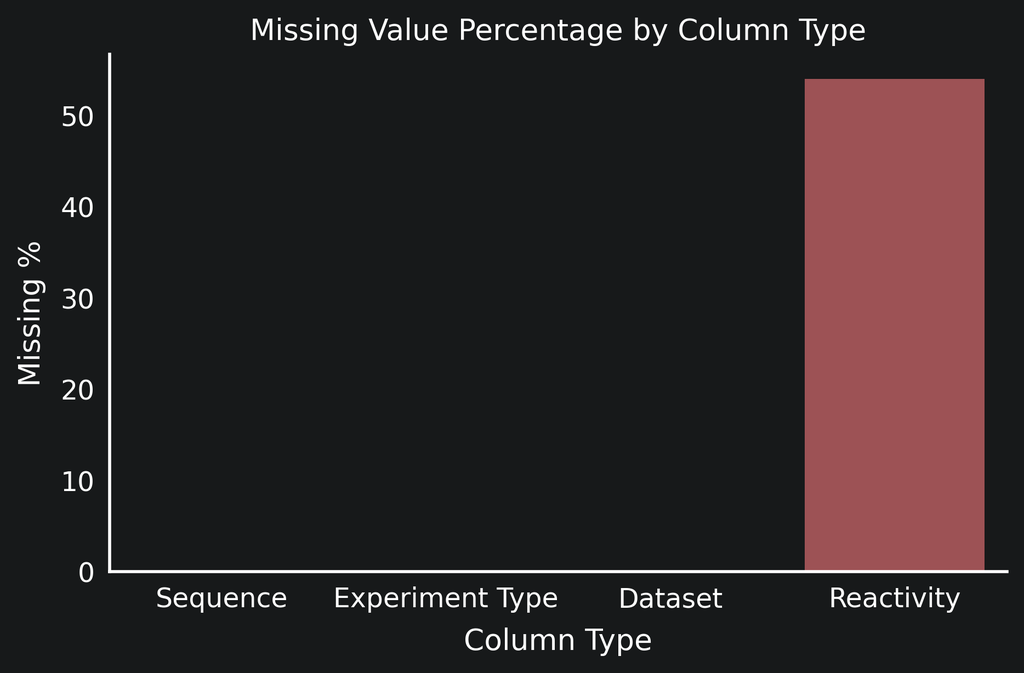

```python
# === SUMMARY PRINT ===
print("=== SUMMARY OF KEY COLUMN TYPES ===\n")

summary_data = []  # for plotting

# Sequence column
if col_sequence:
    total = len(train)
    na_count = train[col_sequence].isna().sum()
    na_pct = na_count / total * 100
    summary_data.append(("Sequence", na_pct))
    print(f"Sequence column: {col_sequence}")
    print(f"Non-null count: {total - na_count}")
    print(f"Missing count: {na_count} ({na_pct:.2f}%)")
    print(f"Unique sequences: {train[col_sequence].nunique()}\n")
else:
    print("No sequence column found.\n")

# Experiment type column
if col_exp_type:
    total = len(train)
    na_count = train[col_exp_type].isna().sum()
    na_pct = na_count / total * 100
    summary_data.append(("Experiment Type", na_pct))
    print(f"Experiment type column: {col_exp_type}")
    print(f"Non-null count: {total - na_count}")
    print(f"Missing count: {na_count} ({na_pct:.2f}%)")
    print(f"Unique experiment types: {train[col_exp_type].nunique()}")
    print(f"Top 5 experiment types:\n{train[col_exp_type].value_counts().head()}\n")
else:
    print("No experiment type column found.\n")

# Dataset column
if col_dataset:
    total = len(train)
    na_count = train[col_dataset].isna().sum()
    na_pct = na_count / total * 100
    summary_data.append(("Dataset", na_pct))
    print(f"Dataset column: {col_dataset}")
    print(f"Non-null count: {total - na_count}")
    print(f"Missing count: {na_count} ({na_pct:.2f}%)")
    print(f"Unique datasets: {train[col_dataset].nunique()}")
    print(f"Top 5 datasets:\n{train[col_dataset].value_counts().head()}\n")
else:
    print("No dataset column found.\n")

# Reactivity columns
if reactivity_cols:
    reactivity_df = train[reactivity_cols]
    na_pct_avg = reactivity_df.isna().mean().mean() * 100
    summary_data.append(("Reactivity", na_pct_avg))
    print(f"Reactivity columns: {len(reactivity_cols)} found")
    print(f"Column range: {reactivity_cols[0]} → {reactivity_cols[-1]}")
    print(f"Average missing values: {na_pct_avg:.2f}%")
    print(f"Mean (overall): {reactivity_df.mean().mean():.4f}")
    print(f"Std (overall): {reactivity_df.std().mean():.4f}\n")
else:
    print("No reactivity columns found.\n")

# =============== PLOT MISSING SUMMARY =============== #

if summary_data:
    summary_df = pd.DataFrame(summary_data, columns=["Column Type", "Missing %"])

    # Style
    sns.set_theme(style="white", rc={
        "axes.facecolor": dark_col,
        "figure.facecolor": dark_col,
        "axes.grid": False
    })

    plt.figure(figsize=(6,4))
    ax = sns.barplot(
        data=summary_df,
        x="Column Type",
        y="Missing %",
        alpha=0.85,
        edgecolor=None,   # <-- remove bar stroke
        linewidth=0       # <-- ensure no outline even if seaborn tries
    )

    # Minimal axes style
    ax.set_title("Missing Value Percentage by Column Type", color="white", pad=6)
    ax.set_xlabel("Column Type", color="white", labelpad=6)
    ax.set_ylabel("Missing %", color="white", labelpad=6)
    ax.tick_params(colors="white", length=3, width=1, pad=3)

    # Keep x/y axes only
    for spine in ["top","right"]:
        ax.spines[spine].set_visible(False)
    ax.spines["left"].set_color("white")
    ax.spines["bottom"].set_color("white")

    plt.tight_layout()
    plt.savefig("Missing_Value_per_col.png", bbox_inches="tight")
    plt.show()
```

## 4. Sequence properties

Explore sequence length distribution and base composition.

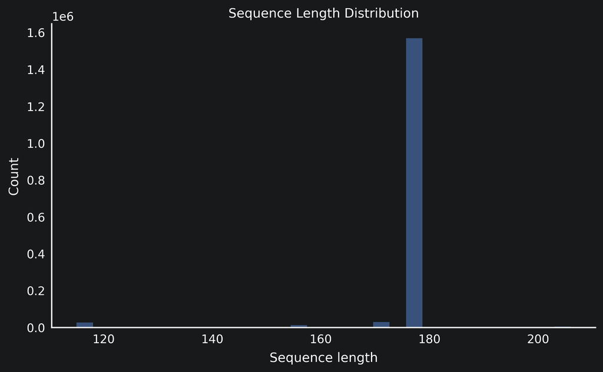

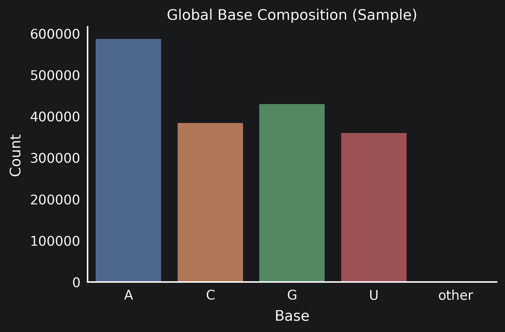

```python
import warnings
warnings.filterwarnings("ignore", message="use_inf_as_na option is deprecated")
warnings.filterwarnings("ignore", message="Pass `\(name,\)` instead of `name`")
warnings.filterwarnings("ignore", category=FutureWarning, module="seaborn._oldcore")

def seq_len(s):
    return len(s) if isinstance(s, str) else np.nan

# Common axis styling
def style_axes(ax, title, xlabel, ylabel):
    ax.set_title(title, color="white", pad=6)
    ax.set_xlabel(xlabel, color="white", labelpad=6)
    ax.set_ylabel(ylabel, color="white", labelpad=6)
    ax.tick_params(colors="white", length=3, width=1, pad=3)

    # keep only left + bottom spines
    for spine in ["top", "right"]:
        ax.spines[spine].set_visible(False)
    ax.spines["left"].set_color("white")
    ax.spines["bottom"].set_color("white")

if col_sequence:
    # === Compute lengths ===
    lengths = train[col_sequence].astype("object").map(seq_len)

    # Sequence length distribution (NO stroke)
    plt.figure(figsize=(8,5))
    ax = sns.histplot(
        x=lengths,
        bins=30,
        stat="count",
        alpha=0.65,
        element="bars",      # <-- bars instead of step (removes outline)
        linewidth=0,         # <-- no stroke line
        edgecolor=None       # <-- no edge color
    )
    style_axes(ax, "Sequence Length Distribution", "Sequence length", "Count")
    plt.tight_layout()
    plt.savefig("Sequence_Length.png", bbox_inches="tight")
    plt.show()

    # Global base composition
    SAMPLE_N = min(10000, len(train))
    seq_sample = train[col_sequence].dropna().astype(str).sample(SAMPLE_N, random_state=42)

    counts = {'A':0, 'C':0, 'G':0, 'U':0, 'other':0}
    for s in seq_sample:
        for ch in s:
            counts[ch if ch in counts else 'other'] += 1

    comp = pd.Series(counts)

    plt.figure(figsize=(6,4))
    ax = sns.barplot(
        x=comp.index,
        y=comp.values,
        alpha=0.85,
        edgecolor=None,   # <-- remove bar stroke
        linewidth=0       # <-- ensure no outline even if seaborn tries
    )
    style_axes(ax, "Global Base Composition (Sample)", "Base", "Count")
    plt.tight_layout()
    plt.savefig("Base_Composition.png", bbox_inches="tight")
    plt.show()
```

## 5. Reactivity overview

Summary statistics and per-position patterns.

```
count    1.557642e+08
mean     3.414254e-01
std      1.329081e+00
min     -1.292810e+02
25%      0.000000e+00
50%      0.000000e+00
75%      3.870000e-01
max      1.292810e+02
dtype: float64
```

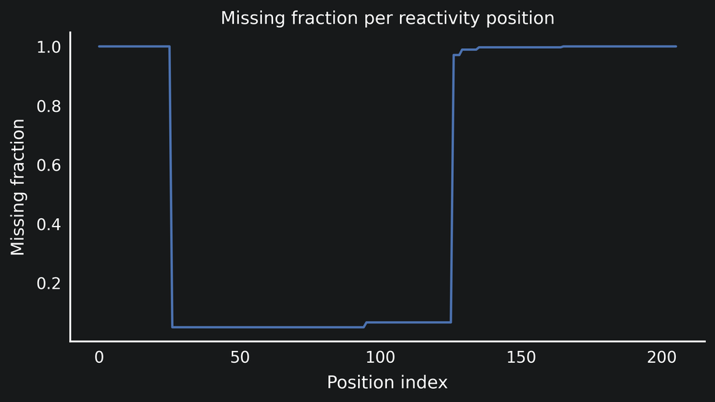

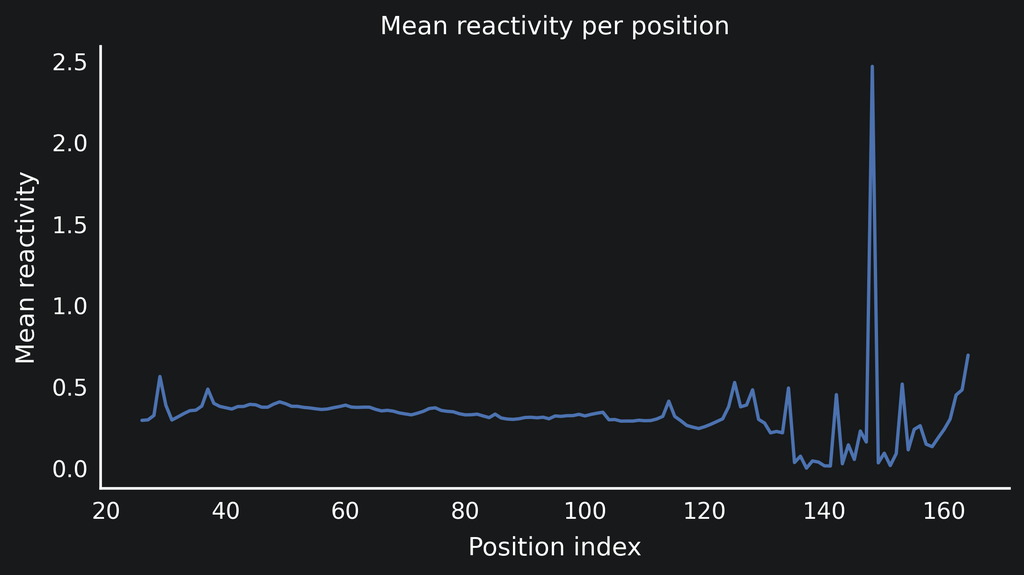

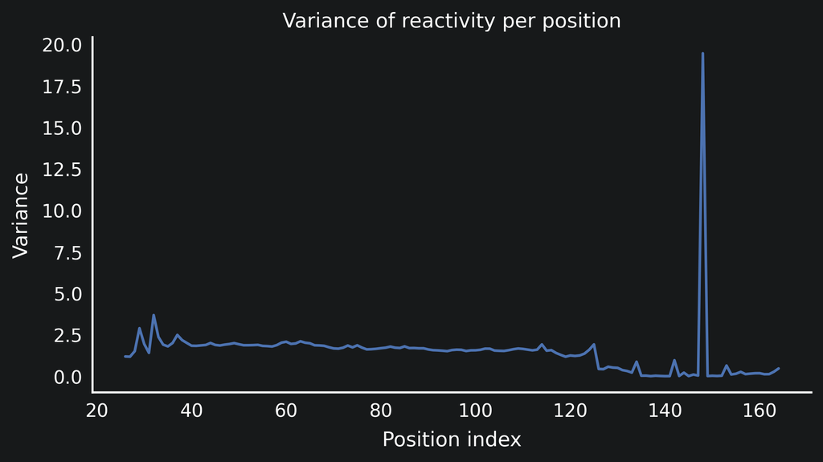

```python
if reactivity_cols:
    # Same describe() output
    desc = pd.concat([train[c] for c in reactivity_cols], axis=0).describe()
    print(desc)

    # Precompute arrays
    miss = train[reactivity_cols].isna().mean()
    R = train[reactivity_cols].astype('float32')
    means, vars_ = R.mean(axis=0), R.var(axis=0)

    # Common minimalist axis styling
    def style_axes(ax, title, ylabel):
        ax.set_title(title, color="white", pad=6)
        ax.set_xlabel("Position index", color="white", labelpad=6)
        ax.set_ylabel(ylabel, color="white", labelpad=6)
        ax.tick_params(colors="white", length=3, width=1, pad=3)
        # keep bottom/left axes only
        for spine in ["top","right"]:
            ax.spines[spine].set_visible(False)
        ax.spines["left"].set_color("white")
        ax.spines["bottom"].set_color("white")

    # Missing fraction
    plt.figure(figsize=(7,4))
    ax = sns.lineplot(x=range(len(miss)), y=miss.values, lw=1.6)
    style_axes(ax, "Missing fraction per reactivity position", "Missing fraction")
    plt.tight_layout()
    plt.savefig("reactivity_missing.png", bbox_inches="tight")
    plt.show()

    # Mean
    plt.figure(figsize=(7,4))
    ax = sns.lineplot(x=range(len(means)), y=means.values, lw=1.6)
    style_axes(ax, "Mean reactivity per position", "Mean reactivity")
    plt.tight_layout()
    plt.savefig("reactivity_mean.png", bbox_inches="tight")
    plt.show()

    # Variance
    plt.figure(figsize=(7,4))
    ax = sns.lineplot(x=range(len(vars_)), y=vars_.values, lw=1.6)
    style_axes(ax, "Variance of reactivity per position", "Variance")
    plt.tight_layout()
    plt.savefig("reactivity_variance.png", bbox_inches="tight")
    plt.show()
```

### Reactivity Distribution Plot

Samples RNA reactivity values, builds histogram bins (central 98% range), groups by experiment type if available, and plots step-line histograms without melting the DataFrame. Ensures reproducible sampling, ignores error columns, and keeps a clean axis-focused style.

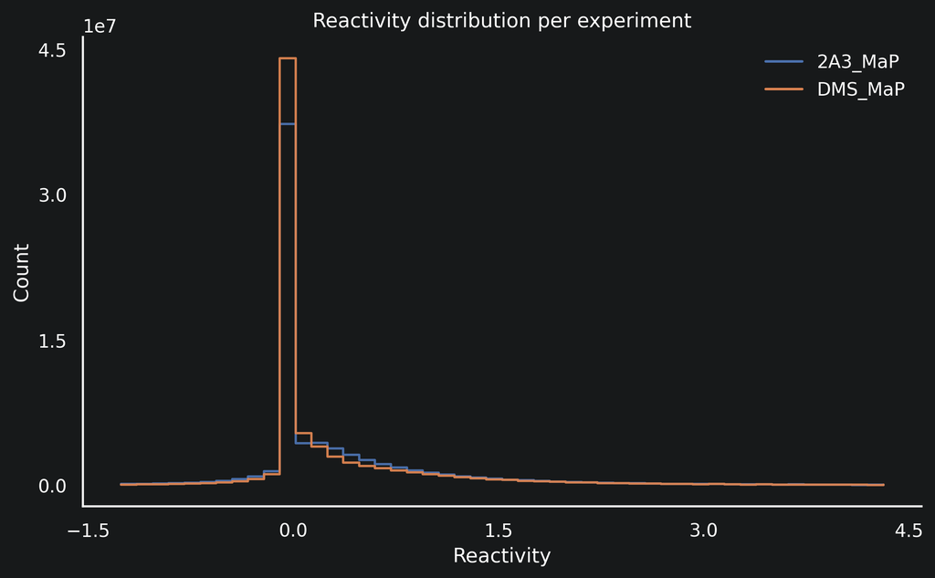

```python
# Filter valid reactivity columns (exclude "*error*")
react_cols = [c for c in reactivity_cols if "error" not in str(c).lower()] if reactivity_cols else []
if not react_cols:
    raise ValueError("No reactivity columns found to plot.")

# Ensure hue (experiment type) is categorical if present
has_hue = col_exp_type in train.columns if col_exp_type is not None else False
if has_hue and not isinstance(train[col_exp_type].dtype, pd.CategoricalDtype):
    train[col_exp_type] = train[col_exp_type].astype("category")

# RNG for reproducible row sampling
rng = np.random.default_rng(0)

# Sample rows to estimate distribution range (fast)
n = len(train)
idx = rng.choice(n, size=min(n, 100_000), replace=False)
vals = train.iloc[idx][react_cols].to_numpy(copy=False).ravel()
vals = vals[np.isfinite(vals)]

# Central 98% range bins
lo, hi = np.quantile(vals, [0.01, 0.99])
bins = np.linspace(lo, hi, 50)

# Flatten helper
flat = lambda df: df.to_numpy(copy=False).ravel()

# Count hist per experiment type (or single group)
groups = train.groupby(col_exp_type, observed=True, sort=False) if has_hue else [("all", train)]
records = []
for name, g in groups:
    v = flat(g[react_cols])
    v = v[np.isfinite(v)]
    v = v[(v >= bins[0]) & (v <= bins[-1])]
    h, _ = np.histogram(v, bins)
    for left, cnt in zip(bins[:-1], h):
        records.append({"bin_left": left, "count": int(cnt), "experiment_type": name})

counts_df = pd.DataFrame(records)

# Plot stepped histogram lines
plt.figure(figsize=(8, 5))
ax = sns.lineplot(
    data=counts_df, x="bin_left", y="count", hue="experiment_type",
    estimator=None, drawstyle="steps-post", lw=1.4, alpha=0.95
)

ax.set_xlabel("Reactivity", color="white")
ax.set_ylabel("Count", color="white")

# Ticks + spine style (keep only bottom/left)
ax.set_title("Reactivity distribution per experiment", color="white")
ax.xaxis.set_major_locator(MaxNLocator(5))
ax.yaxis.set_major_locator(MaxNLocator(4))
ax.tick_params(axis="both", colors="white")

ax.spines["left"].set_color("white"); ax.spines["bottom"].set_color("white")
ax.spines["right"].set_visible(False); ax.spines["top"].set_visible(False)

# Legend cleanup
leg = ax.get_legend()
if leg:
    leg.set_title(None); leg.set_frame_on(False)
    for t in leg.get_texts(): t.set_color("white")

plt.savefig("reactivity_histo.png", bbox_inches="tight")

plt.tight_layout(); plt.show()
```

### RNA Reactivity — Base-wise Summary + Export + Plot

This workflow computes nucleotide-specific (A/C/G/U) reactivity statistics for each experiment condition, builds a tidy summary table, saves it to Markdown, and visualizes mean reactivity with standard error on a dark-styled grouped bar chart. It handles experiment ordering, missing data, variable sequence lengths, and uses fully vectorized operations for efficiency on large RNA datasets.

```python
# === Input validation ===
# Ensure sequence column and reactivity columns exist
if col_sequence is None:
    raise ValueError("Need a sequence-like column (e.g., 'sequence') to compute Base groups.")
if not reactivity_cols:
    raise ValueError("No reactivity_* columns detected.")
exp_col = col_exp_type if col_exp_type is not None else None

# === Prepare experiment column with fixed ordering (preferred first) ===
if exp_col is None:
    train["_EXP_FALLBACK"] = "ALL"               # fallback label
    exp_col = "_EXP_FALLBACK"

exp_vals = train[exp_col].astype("string")
preferred = ["2A3", "DMS"]                       # user-preferred experiments first
cats = [p for p in preferred if p in set(exp_vals.dropna())] + \
       sorted([x for x in exp_vals.dropna().unique() if x not in preferred])
train[exp_col] = pd.Categorical(exp_vals, categories=cats, ordered=True)
exps = list(train[exp_col].cat.categories)

# === Build reactivity matrix sorted by numeric position ===
pos_nums = pd.Series(reactivity_cols).str.extract(r"reactivity_(\d+)", expand=False).astype(int)
use_cols = [reactivity_cols[i] for i in np.argsort(pos_nums)]
R = train[use_cols].to_numpy(dtype=np.float32, copy=False)
N, L = R.shape
finite_mask = np.isfinite(R)                      # valid numeric values only

# === Convert sequence column to aligned base matrix (N × L) ===
seq = train[col_sequence].astype("string").fillna("").str.upper()
try:
    arr = np.array(seq.tolist(), dtype=f"U{L}")  # fast path if all same length
    bmat = np.char.array(arr).view('U1').reshape(-1, L)
except Exception:                                # fallback if variable length
    bmat = np.full((N, L), " ", dtype="U1")
    for j in range(L):
        col = seq.str.get(j)
        if not col.isna().all():
            bmat[:, j] = col.fillna(" ").to_numpy()

bases_order = ["A", "C", "G", "U"]

# === Encode experiment groups numeric for fast indexing ===
codes = train[exp_col].cat.codes.to_numpy()
exps = list(train[exp_col].cat.categories)

# === Define function to compute boxplot-like stats quickly ===
def box_stats_np(x):
    x = x[np.isfinite(x)]
    if x.size == 0:
        return dict(median=np.nan, q1=np.nan, q3=np.nan, whislo=np.nan, whishi=np.nan,
                    mean=np.nan, std=np.nan, count=0)
    q1, med, q3 = np.quantile(x, [0.25, 0.5, 0.75])
    iqr = q3 - q1
    lo, hi = q1 - 1.5 * iqr, q3 + 1.5 * iqr
    whislo = float(x[x >= lo].min()) if (x >= lo).any() else float(q1)
    whishi = float(x[x <= hi].max()) if (x <= hi).any() else float(q3)
    return dict(
        median=float(med), q1=float(q1), q3=float(q3),
        whislo=whislo, whishi=whishi,
        mean=float(x.mean()),
        std=float(x.std(ddof=1)) if x.size > 1 else np.nan,
        count=int(x.size)
    )

# === Compute stats across all experiments and bases ===
stats_rows = []
for ei, exp_name in enumerate(exps):
    emask = (codes == ei)
    R_e = R[emask]
    F_e = finite_mask[emask]
    B_e = bmat[emask]

    for base in bases_order:
        mask = F_e & (B_e == base)               # finite + matching base
        vals = R_e[mask] if mask.any() else np.array([], dtype=np.float32)
        s = box_stats_np(vals)

        stats_rows.append({
            "Experiment": exp_name, "Base": base,
            "Count": s["count"], "Mean": s["mean"], "Std": s["std"],
            "Q1": s["q1"], "Median": s["median"], "Q3": s["q3"],
            "IQR": s["q3"] - s["q1"], "Whisker Low": s["whislo"], "Whisker High": s["whishi"],
        })

# === Final DataFrame ordered nicely ===
stats_df = pd.DataFrame(stats_rows).sort_values(["Base", "Experiment"])
```

```python
# Show full formatted table in notebook
with pd.option_context("display.max_rows", None,
                       "display.max_columns", None,
                       "display.precision", 4,
                       "display.colheader_justify", "center"):
    display(stats_df.sort_values(["Experiment", "Base"]))

# Save same table to markdown file
md_table = stats_df.round(4).to_markdown(index=False)
with open("stats_summary.md", "w") as f:
    f.write(md_table)
```

|  | Experiment | Base | Count | Mean | Std | Q1 | Median | Q3 | IQR | Whisker Low | Whisker High |
| --- | --- | --- | --- | --- | --- | --- | --- | --- | --- | --- | --- |
| 0 | 2A3_MaP | A | 21843638 | 0.4099 | 1.4151 | 0.0 | 0.000 | 0.501 | 0.501 | -0.751 | 1.252 |
| 1 | 2A3_MaP | C | 16355431 | 0.1952 | 1.2322 | 0.0 | 0.000 | 0.220 | 0.220 | -0.329 | 0.550 |
| 2 | 2A3_MaP | G | 19116267 | 0.2455 | 1.5479 | 0.0 | 0.000 | 0.371 | 0.371 | -0.556 | 0.927 |
| 3 | 2A3_MaP | U | 19848569 | 0.5045 | 1.5779 | 0.0 | 0.012 | 0.702 | 0.702 | -1.053 | 1.755 |
| 4 | DMS_MaP | A | 22241026 | 0.7281 | 1.5733 | 0.0 | 0.283 | 0.992 | 0.992 | -1.487 | 2.480 |
| 5 | DMS_MaP | C | 16635084 | 0.4684 | 1.3083 | 0.0 | 0.000 | 0.557 | 0.557 | -0.835 | 1.392 |
| 6 | DMS_MaP | G | 19466073 | 0.0778 | 0.8348 | 0.0 | 0.000 | 0.087 | 0.087 | -0.130 | 0.217 |
| 7 | DMS_MaP | U | 20258079 | 0.0410 | 0.5590 | 0.0 | 0.000 | 0.000 | 0.000 | 0.000 | 0.000 |

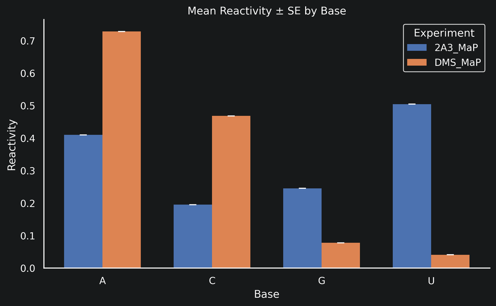

```python
# Compute Standard Error
stats_df = stats_df.copy()
stats_df["SE"] = stats_df["Std"] / np.sqrt(stats_df["Count"])

# Order bases + experiments
bases_order = ["A", "C", "G", "U"]
preferred_exps = ["2A3", "DMS"]
exps_all = list(pd.unique(stats_df["Experiment"]))
exps = [e for e in preferred_exps if e in exps_all] + [e for e in exps_all if e not in preferred_exps]

# Filter + set categorical ordering for plot
stats_df = stats_df[stats_df["Base"].isin(bases_order) & stats_df["Experiment"].isin(exps)].copy()
stats_df["Base"] = pd.Categorical(stats_df["Base"], bases_order, ordered=True)
stats_df["Experiment"] = pd.Categorical(stats_df["Experiment"], exps, ordered=True)

# Dark style
plt.rcParams.update({
    "axes.facecolor": dark_col,"figure.facecolor": dark_col,
    "axes.edgecolor": "white","xtick.color": "white",
    "ytick.color": "white","text.color": "white","axes.grid": False
})

fig, ax = plt.subplots(figsize=(8, 5))
fig.patch.set_facecolor(dark_col); ax.set_facecolor(dark_col)

# Bar positions
x = np.arange(len(bases_order))
group_width = 0.7
w = group_width / max(1, len(exps))
offset = -group_width/2 + w/2

palette = ["#4C72B0", "#DD8452"] + ["#888888"] * max(0, len(exps)-2)

# Draw bars + error bars
for i, exp in enumerate(exps):
    sub = stats_df[stats_df["Experiment"] == exp].set_index("Base")
    ax.bar(x + offset + i*w,
           sub["Mean"], width=w,
           yerr=sub["SE"], capsize=4,
           label=str(exp),
           color=palette[i], edgecolor=None, ecolor="white",
           linewidth=0, error_kw=dict(lw=1.8))

# Labels/ticks
ax.set_title("Mean Reactivity ± SE by Base", color="white")
ax.set_xlabel("Base", color="white")
ax.set_ylabel("Reactivity", color="white")
ax.set_xticks(x); ax.set_xticklabels(bases_order)
ax.tick_params(colors="white")

# Spines
for side in ["top", "right"]: ax.spines[side].set_visible(False)
ax.spines["left"].set_color("white"); ax.spines["bottom"].set_color("white")

# Legend style
leg = ax.legend(title="Experiment")
plt.setp(leg.get_title(), color="white"); plt.setp(leg.get_texts(), color="white")
leg.get_frame().set_facecolor(dark_col); leg.get_frame().set_edgecolor("white")
plt.savefig("reactivity_boxplot.png", bbox_inches="tight")
plt.tight_layout(); plt.show()
```